This is a simple analysis that I've done using R with [Students Performance in Exams](https://www.kaggle.com/spscientist/students-performance-in-exams) in Kaggle.

## Loading the library

```r
library(ggplot2)
library(dplyr)
library(gridExtra)
library(fastDummies)
library(caTools)
library(randomForest)
library(caret)
library(broom)
```

## Reading the data

```r
data <- read.csv('./data/StudentsPerformance.csv')
data <- data %>%
  mutate(average = (reading.score + math.score + writing.score) / 3) %>%
  mutate(race.ethnicity = substr(race.ethnicity, 7, 7)) %>%
  mutate(test.preparation.course = test.preparation.course == "completed") %>%
  mutate(lunch = lunch == "standard")
head(data)
```

|  | gender | race.ethnicity | parental.level.of.education | lunch | test.preparation.course | math.score | reading.score | writing.score | average |
| --- | --- | --- | --- | --- | --- | --- | --- | --- | --- |
| 1 | female | B | bachelor's degree | TRUE | FALSE | 72 | 72 | 74 | 72.66667 |
| 2 | female | C | some college | TRUE | TRUE | 69 | 90 | 88 | 82.33333 |
| 3 | female | B | master's degree | TRUE | FALSE | 90 | 95 | 93 | 92.66667 |
| 4 | male | A | associate's degree | FALSE | FALSE | 47 | 57 | 44 | 49.33333 |
| 5 | male | C | some college | TRUE | FALSE | 76 | 78 | 75 | 76.33333 |
| 6 | female | B | associate's degree | TRUE | FALSE | 71 | 83 | 78 | 77.33333 |

```r
# Edit the levels of education
levels(data$parental.level.of.education)[match("high school",levels(data$parental.level.of.education))] <- "hs"

levels(data$parental.level.of.education)[match("master's degree",levels(data$parental.level.of.education))] <- "md"

levels(data$parental.level.of.education)[match("bachelor's degree",levels(data$parental.level.of.education))] <- "bd"

levels(data$parental.level.of.education)[match("some college",levels(data$parental.level.of.education))] <- "c"

levels(data$parental.level.of.education)[match("associate's degree",levels(data$parental.level.of.education))] <- "as"

levels(data$parental.level.of.education)[match("some high school",levels(data$parental.level.of.education))] <- "h"
```

## Exploring the factor columns

```r
explore_boxplot <- function(mv){
  p <- list()
  for (rv in names(data[, 6:9])) {
    tmp <- ggplot(data) +
      geom_boxplot(aes_string(x = mv, y = rv))
    p[[length(p) + 1]] <- tmp
  }
  do.call(grid.arrange, c(p))
}
```

### Gender

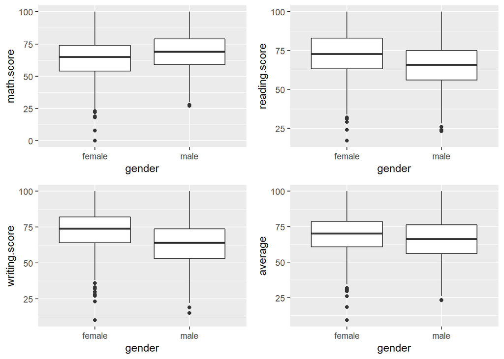

```r
explore_boxplot("gender")
```

- Looks like gender does affect the scores, on average both are quite balanced
- But males do better in Math while Females do better in writing & reading

### Race

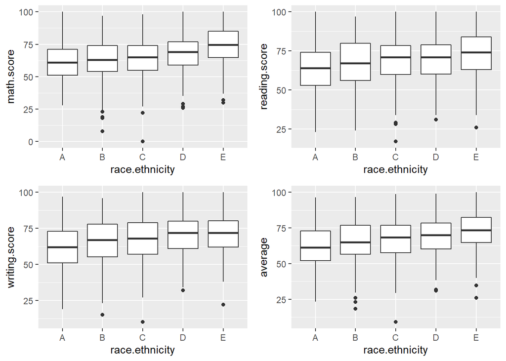

```r
explore_boxplot("race.ethnicity")
```

- Can’t say for sure, but a rough look tells me that race will affect too!
- Race group E seems like doing better than other races while A looks like it is not doing as well.

### Lunch

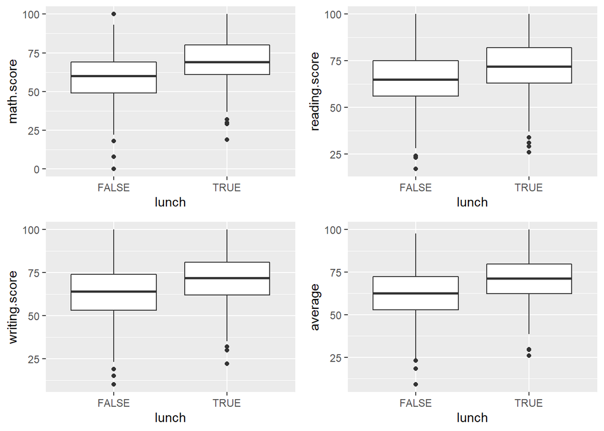

```r
explore_boxplot("lunch")
```

- TRUE lunch indicates standard lunch
- This conforms to expectation where good lunch gives better score,
- So here can give a short conclusion: Eat good lunch for better score :D

### Test Preparation

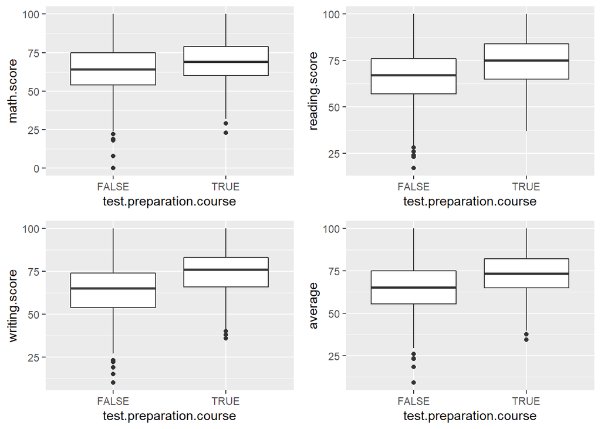

```r
explore_boxplot("test.preparation.course")
```

- Again, as expected, the students who took test preparation course performed better than those who did not take.

### Parent's Education

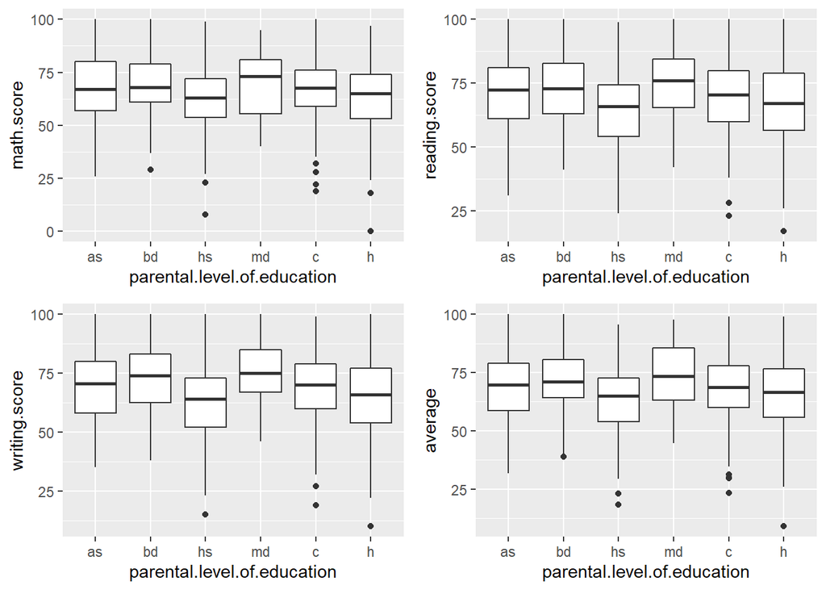

```r
explore_boxplot("parental.level.of.education")
```

- There definitely exists a relationship between parent’s education level and the children’s scores, but it isn’t as clear and direct as other relationships.
- A rough glance, though, tells me that students’ parents with just high school levelof education perform the worse.

## Confirming the relationship

- Unlike the other 4 properties, parent’s level of education’s effect on the student might not be as significant. Perhaps I will try a T test on a linear model with parent’s level of education.
- Assuming sigma = 0.05.

```r
mod <- lm(average ~ parental.level.of.education, data = data)
summary(mod)
```

```
##
## Call:
## lm(formula = average ~ parental.level.of.education, data = data)
##
## Residuals:
##     Min      1Q  Median      3Q     Max
## -56.108  -9.259   0.874   9.895  33.892
##
## Coefficients:
##                               Estimate Std. Error t value Pr(>|t|)
## (Intercept)                    69.5691     0.9344  74.457  < 2e-16 ***
## parental.level.of.educationbd   2.3547     1.5860   1.485  0.13796
## parental.level.of.educationhs  -6.4721     1.3645  -4.743 2.41e-06 ***
## parental.level.of.educationmd   4.0298     2.0391   1.976  0.04840 *
## parental.level.of.educationc   -1.0927     1.3155  -0.831  0.40640
## parental.level.of.educationh   -4.4611     1.3985  -3.190  0.00147 **
## ---
## Signif. codes:  0 '***' 0.001 '**' 0.01 '*' 0.05 '.' 0.1 ' ' 1
##
## Residual standard error: 13.92 on 994 degrees of freedom
## Multiple R-squared:  0.05131,    Adjusted R-squared:  0.04654
## F-statistic: 10.75 on 5 and 994 DF,  p-value: 4.381e-10
```

## Testing with a simple linear model

```r
model <- lm(math.score ~ parental.level.of.education + test.preparation.course + lunch + gender + race.ethnicity, data = data)
summary(model)
```

```
##
## Call:
## lm(formula = math.score ~ parental.level.of.education + test.preparation.course +
##     lunch + gender + race.ethnicity, data = data)
##
## Residuals:
##     Min      1Q  Median      3Q     Max
## -50.357  -8.744   0.166   9.001  30.655
##
## Coefficients:
##                               Estimate Std. Error t value Pr(>|t|)
## (Intercept)                    52.1358     1.8115  28.780  < 2e-16 ***
## parental.level.of.educationbd   1.9661     1.5020   1.309 0.190831
## parental.level.of.educationhs  -4.8027     1.2971  -3.703 0.000225 ***
## parental.level.of.educationmd   2.8884     1.9382   1.490 0.136490
## parental.level.of.educationc   -0.5827     1.2470  -0.467 0.640431
## parental.level.of.educationh   -4.2487     1.3331  -3.187 0.001482 **
## test.preparation.courseTRUE     5.4947     0.8756   6.275 5.22e-10 ***
## lunchTRUE                      10.8768     0.8727  12.463  < 2e-16 ***
## gendermale                      4.9953     0.8390   5.954 3.63e-09 ***
## race.ethnicityB                 2.0408     1.6998   1.201 0.230181
## race.ethnicityC                 2.4700     1.5918   1.552 0.121060
## race.ethnicityD                 5.3410     1.6241   3.289 0.001042 **
## race.ethnicityE                10.1347     1.8015   5.626 2.41e-08 ***
## ---
## Signif. codes:  0 '***' 0.001 '**' 0.01 '*' 0.05 '.' 0.1 ' ' 1
##
## Residual standard error: 13.17 on 987 degrees of freedom
## Multiple R-squared:  0.2548, Adjusted R-squared:  0.2457
## F-statistic: 28.12 on 12 and 987 DF,  p-value: < 2.2e-16
```

- Looking at how some values are insignificant, perhaps I will create a dummy variable & split the data into training and test data.

## Creating dummy variables & cleaning the data

```r
cleaned <- dummy_cols(data, select_columns = c("gender", "race.ethnicity",
                                               "parental.level.of.education",
                                               "lunch", "test.preparation.course"), remove_selected_columns = TRUE)

head(cleaned)
```

|  | math.score | reading.score | writing.score | average | gender_female | gender_male | race.ethnicity_A | race.ethnicity_B | race.ethnicity_C | race.ethnicity_D | race.ethnicity_E | parental.level.of.education_as | parental.level.of.education_bd | parental.level.of.education_hs | parental.level.of.education_md | parental.level.of.education_c | parental.level.of.education_h | lunch_FALSE | lunch_TRUE | test.preparation.course_FALSE | test.preparation.course_TRUE |
| --- | --- | --- | --- | --- | --- | --- | --- | --- | --- | --- | --- | --- | --- | --- | --- | --- | --- | --- | --- | --- | --- |
| 1 | 72 | 72 | 74 | 72.66667 | 1 | 0 | 0 | 1 | 0 | 0 | 0 | 0 | 1 | 0 | 0 | 0 | 0 | 0 | 1 | 1 | 0 |
| 2 | 69 | 90 | 88 | 82.33333 | 1 | 0 | 0 | 0 | 1 | 0 | 0 | 0 | 0 | 0 | 0 | 1 | 0 | 0 | 1 | 0 | 1 |
| 3 | 90 | 95 | 93 | 92.66667 | 1 | 0 | 0 | 1 | 0 | 0 | 0 | 0 | 0 | 0 | 1 | 0 | 0 | 0 | 1 | 1 | 0 |
| 4 | 47 | 57 | 44 | 49.33333 | 0 | 1 | 1 | 0 | 0 | 0 | 0 | 1 | 0 | 0 | 0 | 0 | 0 | 1 | 0 | 1 | 0 |
| 5 | 76 | 78 | 75 | 76.33333 | 0 | 1 | 0 | 0 | 1 | 0 | 0 | 0 | 0 | 0 | 0 | 1 | 0 | 0 | 1 | 1 | 0 |
| 6 | 71 | 83 | 78 | 77.33333 | 1 | 0 | 0 | 1 | 0 | 0 | 0 | 1 | 0 | 0 | 0 | 0 | 0 | 0 | 1 | 1 | 0 |

```r
# Dropping redundant columns
redundants <- c("race.ethnicity_E", "gender_male", "parental.level.of.education_h", "lunch_TRUE", "test.preparation.course_TRUE")
cleaned <- cleaned[, !(names(cleaned) %in% redundants)]
head(cleaned)
```

|  | math.score | reading.score | writing.score | average | gender_female | race.ethnicity_A | race.ethnicity_B | race.ethnicity_C | race.ethnicity_D | parental.level.of.education_as | parental.level.of.education_bd | parental.level.of.education_hs | parental.level.of.education_md | parental.level.of.education_c | lunch_FALSE | test.preparation.course_FALSE |
| --- | --- | --- | --- | --- | --- | --- | --- | --- | --- | --- | --- | --- | --- | --- | --- | --- |
| 1 | 72 | 72 | 74 | 72.66667 | 1 | 0 | 1 | 0 | 0 | 0 | 1 | 0 | 0 | 0 | 0 | 1 |
| 2 | 69 | 90 | 88 | 82.33333 | 1 | 0 | 0 | 1 | 0 | 0 | 0 | 0 | 0 | 1 | 0 | 0 |
| 3 | 90 | 95 | 93 | 92.66667 | 1 | 0 | 1 | 0 | 0 | 0 | 0 | 0 | 1 | 0 | 0 | 1 |
| 4 | 47 | 57 | 44 | 49.33333 | 0 | 1 | 0 | 0 | 0 | 1 | 0 | 0 | 0 | 0 | 1 | 1 |
| 5 | 76 | 78 | 75 | 76.33333 | 0 | 0 | 0 | 1 | 0 | 0 | 0 | 0 | 0 | 1 | 0 | 1 |
| 6 | 71 | 83 | 78 | 77.33333 | 1 | 0 | 1 | 0 | 0 | 1 | 0 | 0 | 0 | 0 | 0 | 1 |

```r
splitted <- sample.split(cleaned$average, SplitRatio = 0.8)
train <- cleaned[splitted == TRUE, ]
test <- cleaned[splitted == FALSE, ]

dim(train)
```

```
## [1] 811  16
```

```r
dim(test)
```

```
## [1] 189  16
```